# STAT 385 Homework Assignment 01

Andro Manukov

Due by 12:00 PM 09/14/2019

## R Markdown Introduction

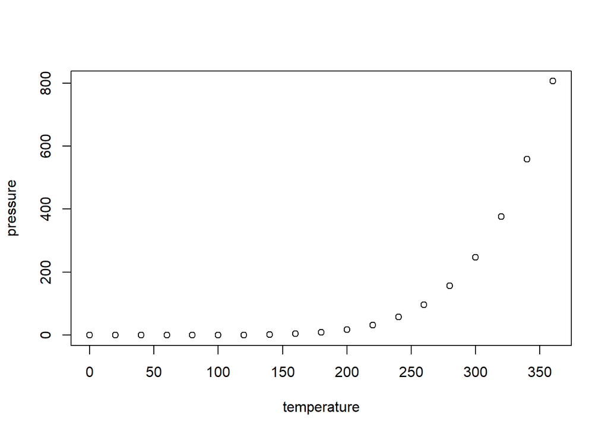

## The Homework Problems

Below you will find problems for you to complete as an individual. It is fine to discuss the homework problems with classmates, but cheating is prohibited and will be harshly penalized if detected.

### 1. With the `data(pressure)` dataset in R, do the following:

1. run the command that shows the help page of the median function

```r
help(median)
```

```
## starting httpd help server ... done
```

2. show the first 10 rows and 2 columns of the `data(pressure)` dataset

```r
head(pressure, n = 10)
```

```
##    temperature pressure
## 1            0   0.0002
## 2           20   0.0012
## 3           40   0.0060
## 4           60   0.0300
## 5           80   0.0900
## 6          100   0.2700
## 7          120   0.7500
## 8          140   1.8500
## 9          160   4.2000
## 10         180   8.8000
```

3. run the command `head(pressure)`

```r
head(pressure)
```

```
##   temperature pressure
## 1           0   0.0002
## 2          20   0.0012
## 3          40   0.0060
## 4          60   0.0300
## 5          80   0.0900
## 6         100   0.2700
```

4. describe the differences between parts **b** and **c**.

1. the median of the stopping distance

```r
median(cars$dist)
```

```
## [1] 36
```

2. the mean of the speed

```r
mean(cars$speed)
```

```
## [1] 15.4
```

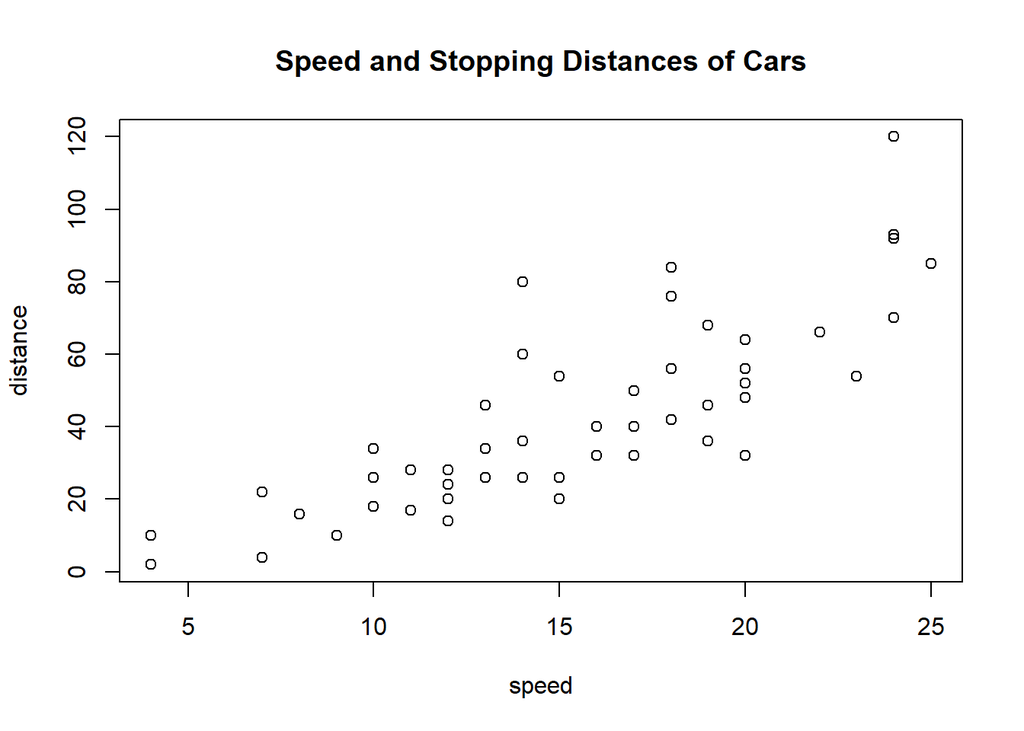

```r
plot(cars, main = "Speed and Stopping Distances of Cars", xlab = "speed", ylab = "distance")
```

### 3. With the `data(iris)` dataset in R, do the following calculations:

```r
sum((iris$Sepal.Length[25] + iris$Sepal.Length[26]) / 2 )
```

```
## [1] 4.9
```

2. the sum of all petal lengths among all species of iris that are between 0 cm and 3 cm

```r
less_than_3 = subset(iris, iris$Petal.Length <= 3)
sum(less_than_3$Petal.Length)
```

```
## [1] 76.1
```

3. assuming `x` equals the sepal length of the 10th virginica iris, then $4\cdot x/2^3$

```r
all_virginica = subset(iris, iris$Species == "virginica")
x = all_virginica$Sepal.Length[10]
print(4 * x / 2 ^ 3)
```

```
## [1] 3.6
```

```r
all_setosa = subset(iris, iris$Species == "setosa")
x = sum(all_virginica$Sepal.Width)
print(4 * (x / 2) ^ 3)
```

```
## [1] 1644004
```

### 4. Using the Instructor Notes from Week 03, address the following:

1. run the code that appears in slide 20 of the intro_slides.pdf slide deck.

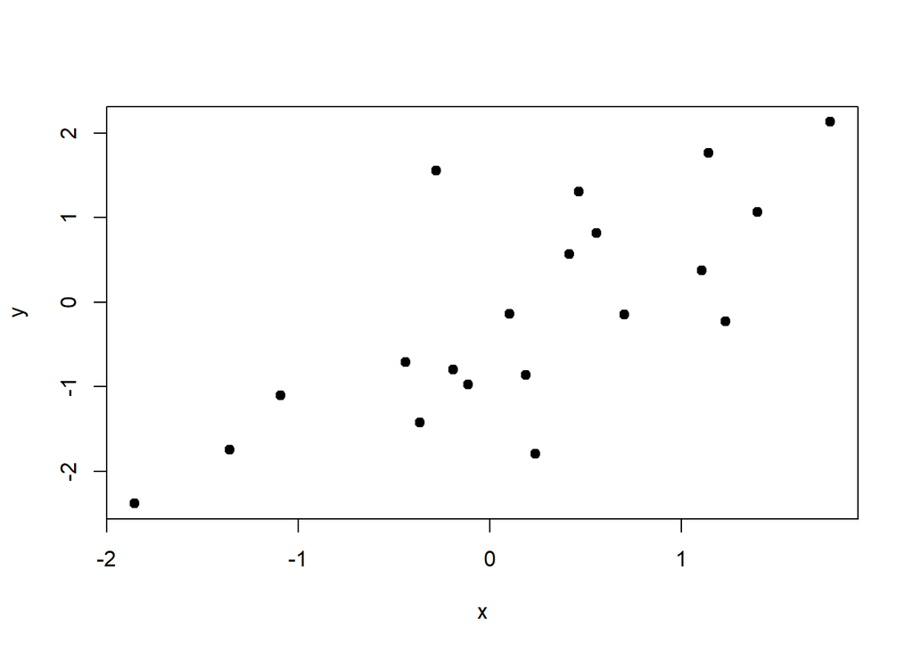

```r
set.seed(13)
x <- rnorm(n = 20)
y <- rnorm(n = 20, mean = x)
plot(y ~ x, pch = 19)
```

2. change the seed number in the `set.seed()` command from 13 to 14. Then, re-run the code in part **a**.

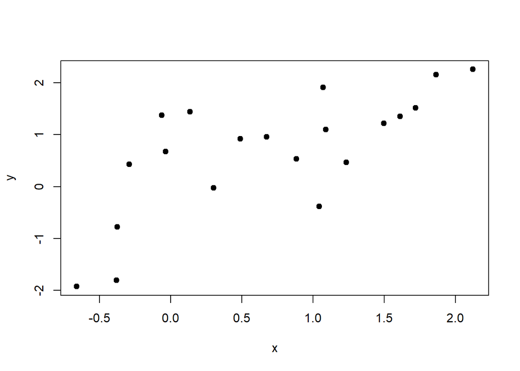

```r
set.seed(14)
x <- rnorm(n = 20)
y <- rnorm(n = 20, mean = x)
plot(y ~ x, pch = 19)
```

c. Is there a difference between the results of parts **a** and **b**? If so, describe some of the obvious differences.

4. Why is it important to set the random seed at the beginning of a simulation?

1. a screenshot that shows your personal repo in GitHub Enterprise

[figure not shown]

2. a screenshot of the Git terminal (or shell) open within RStudio

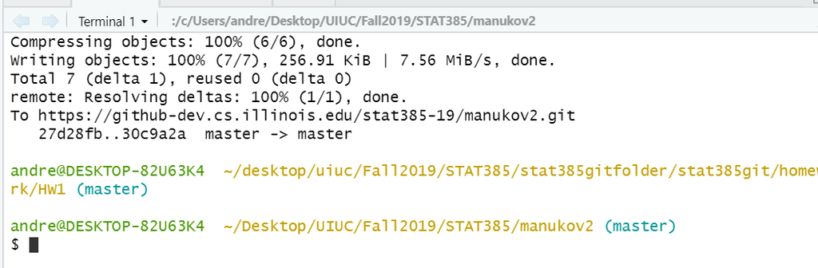

3. a screenshot of RStudio with the 4 panes basic such that there’s a Git tab in the top right pane, and the files in the repo in the bottom right pane

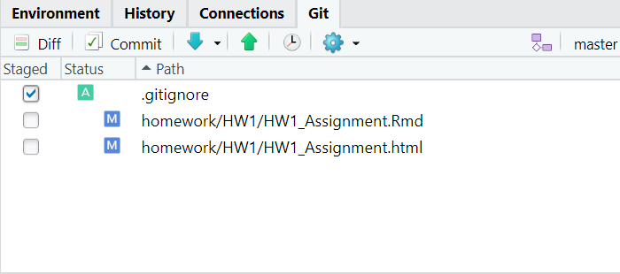

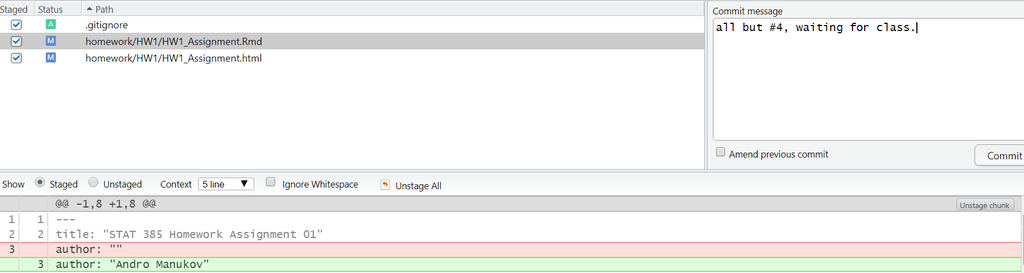